# Curso de R

# Dados de outros pacotes estatísticos

O pacote `haven` possui funções para ler formatos de outros softwares como STATA, SPSS e SAS

| software | função |
| --- | --- |
| SAS | write_sas |
| SAS | read_sas |
| Stata | write_dta |
| Stata | read_dta |
| SPSS | write_sav |
| SPSS | read_sav |

# Dados de bancos de dados

Há inumeros pacotes para ler dados armazenados em bases de dados. Alguns são:

| pacote | Base |
| --- | --- |
| RMySQL | MySQL |
| RDOBC | SQL Server |
| RPostgres | Postgres |
| RSQLite | SQLite |
| rmongodb | MongoDB |
| RCassandra | Cassandra |

# Manipulando dados

## Manipulando dados com o R básico

O curso online realizado já cobriu um pouco da sintaxe de manipulação de dados. Vamos das principais funções.

Toda análise de dados começa importando os dados:

```r
load('Microdados/Censo_Edu_Superior_2014.RDA')
 ls() # quais objetos foram carregados
```

```
## [1] "docente2014" "grad2014"    "ies2014"     "local2014"
```

# Noções gerais dos dados importados

- Funções essenciais para conhecer os dados

| Função | ação |
| --- | --- |
| str() | estrutura dos dados |
| summary() | sumário dos dados, de acordo com a classe |
| class() | classe do objeto |
| length() | tamanho do objeto |
| names() | nomes do objeto |

# A estrutura dos dados

Tente usar a função `str()` nas tabelas importadas:

```r
str(docente2014)

 str(grad2014)

 str(ies2014)

 str(local2014)
```

# Sumário dos dados

Agora vamos conhecer um pouco de algumas variáveis. Tente os comandos abaixo e observe as os resultados no console.

```r
summary(factor(docente2014$DS_CATEGORIA_ADMINISTRATIVA))
 # conta as categorias
 summary(grad2014$QT_VAGAS_NOVAS_EAD)
 # sumário de 6 números
 summary(local2014$DS_LOGRADOURO)
 # informa ser texto
 summary(ies2014)
 # sumário de todas variáveis
```

# Classes, tamanho e nomes

```r
class(docente2014) # data.frame
 class(grad2014$QT_CONCLUINTE_CURSO) # inteiro

 length(local2014) # conta variáeis
 length(local2014$CO_IES) # quantidade de observações

 names(ies2014) # nomes das variáveis
 names(docente2014) # nomes das variáveis
```

# primeiras ou últimas observações

Há também a opçao de você ver apenas algumas observações com as funções `head(objeto, quantidade)` e `tail(objeto, quantidade)`

```r
head(grad2014$QT_CONCLUINTE_CURSO)
 tail(grad2014$QT_CONCLUINTE_CURSO)
 # 6 por padrão

 head(ies2014$VL_RECEITA_PROPRIA, 10)
 # primeiros 10
 tail(docente2014$DS_ESCOLARIDADE_DOCENTE, 3)
 # 3 últimos
```

# Selecionando partes dos dados

Como observamos até agora todas as tabelas são grandes. Para este exercício só precisamos de algumas variáveis. Mas como fazer isso? O **R** básico nós da algumas opções:

- Funções essenciais para selecionar parte dos dados:
1. `[`
2. `[[`
3. `$`
4. subset()
5. with()

# Seleção com [ , ]

A primeira forma de realizar uma seleção é colocar colchetes até o objeto e, dentro dos colchetes, inserir o nome ou indice do valor desejado. No caso de data frames podemos indicar as linhas e colunas que desejamos.

`data.frame[linhas, colunas]`

```r
docente2014[1:1000 , c("NO_IES",
                        "DS_SEXO_DOCENTE",
                        "IN_SUBSTITUTO")]
 # Apenas as primeiras 1000 observações
 # das 3 variáveis selecionadas

 docente2014[1:10 , ] # 10 observações
 docente2014[ ,c("NO_IES",
                 "DS_SEXO_DOCENTE",
                 "IN_SUBSTITUTO")]
 # todas observações das 3 variáveis
```

# Seleção com [[ ]]

A seleção com os colchetes duplos escolhe apenas um elemento do objeto. Também são aceitos tanto o índice quanto o nome.

`objeto[[elemento]]`

Observe que enquanto `[]` retorna um data.frame, `[[]]` retorna apenas o vetor.

```r
ultima <- grad2014[[length(grad2014)]]
 # usando número
 laboratorio <- grad2014[["IN_POSSUI_LABORATORIO"]]
 # usando nome
 laboratorio[[500]]
```

```
## [1] 1
```

```r
# apenas a 500ª observação
```

# Seleção com $

O `$` funciona de modo semelhante ao `[[]]`, isto é, retorna apenas um elemento. Mas há uma diferença, o `$` só aceita nomes para realizar as seleções.

```r
lab <- grad2014$IN_POSSUI_LABORATORIO
 all.equal(lab, laboratorio) # é igual
```

```
## [1] TRUE
```

```r
docente2014$1 # erro
```

```
## Error: <text>:1:13: unexpected numeric constant
 ## 1: docente2014$1
 ##                 ^
```

# Função subset()

A sintaxe da função é como segue:

`subset(x, subset, select, drop = FALSE, ...)`

```r
subst <- subset(docente2014,
                 subset = IN_SUBSTITUTO == 1,
                 select = c("DS_SEXO_DOCENTE", "NU_IDADE_DOCENTE"))

 subst2 <- subset(docente2014,
                 subset = IN_SUBSTITUTO == 1,
                 select = c(17, 21))
 all.equal(subst, subst2)
```

```
## [1] TRUE
```

# Função with()

A funçao `with()` tira a necessidade de ficar digitando a cada vez o nome do objeto principal. Assim,

```r
plot(ies2014$VL_RECEITA_PROPRIA,
      (ies2014$QT_TEC_DOUTORADO_MASC + ies2014$QT_TEC_DOUTORADO_FEM))
```

pode ser reescrita como

```r
with(ies2014,
      plot(x = QT_TEC_DOUTORADO_MASC + QT_TEC_DOUTORADO_FEM,
           y = VL_RECEITA_PROPRIA))
```

# Sintetizando os dados

- Funções essenciais para sumarizar data.frames:

| Função | ação |
| --- | --- |
| lapply() | executa uma função em cada elemento |
| sapply() | idem, resultado simplificado |
| tapply() | iden, dado um critério |
| aggregate() | agrega por algum critério |
| transform() | cria variável calculada |

# lapply e sapply

As funções `lapply()` e `sapply()` executam uma mesma função para para cada elemento de um objeto. No caso dos data frmaes, a função será aplicada em cada variável.

A diferença entre as duas está na objeto que retornam: enquanto lapply retorna uma **sempre** lista, sapply tenta simplificar o resultado para um vetor, matriz ou mesmo um data frame.

# lapply e sapply

```r
classe <- sapply(ies2014, class)
 # classe de todas viariáveis
 sapply(ies2014[, classe == "numeric"],
        mean) /1000000 # em milhões
```

```
##         VL_RECEITA_PROPRIA           VL_TRANSFERENCIA
 ##                 102.734132                  33.833887
 ##           VL_OUTRA_RECEITA VL_DES_PESSOAL_REM_DOCENTE
 ##                  23.320635                  37.546380
 ## VL_DES_PESSOAL_REM_TECNICO     VL_DES_PESSOAL_ENCARGO
 ##                  18.606625                  22.393972
 ##             VL_DES_CUSTEIO        VL_DES_INVESTIMENTO
 ##                  41.580863                   9.319011
 ##            VL_DES_PESQUISA              VL_DES_OUTRAS
 ##                   1.253679                  15.526447
```

```r
# média só dos vetores numéricos
```

# tapply

A função `tapply()` é da mesma família, mas ela leva um argumento a mais, um índice. É como se pedíssemos Execute FUN no vetor X para cada categoria de INDEX

```r
tapply(ies2014$VL_RECEITA_PROPRIA,
        INDEX = ies2014$DS_CATEGORIA_ADMINISTRATIVA,
        FUN = mean)/1000000 # em milhões
```

```
##                    Especial Privada com fins lucrativos
 ##                    49.56429                   140.34667
 ## Privada sem fins lucrativos            Pública Estadual
 ##                    87.62236                    23.75046
 ##             Pública Federal           Pública Municipal
 ##                    44.02261                    11.72985
```

# tapply com sapply

Para ter a média por categoria de instituição para todas as variáveis numéricas bosta aplicar o `tapply()` em cada uma das variáveis numéricas:

```r
sapply(ies2014[, classe == "numeric"], FUN = tapply,
        INDEX = ies2014$DS_CATEGORIA_ADMINISTRATIVA,
        mean)

 # Cuidado com o nome dos argumentos
 # tanto tapply quanto apply tem FUN como argumento
```

# dplyr: uma gramática para manipulação de dados

Antes de mais nada é necessário baixa e carregar o pacote.

```r
install.packages('dplyr') # nome como texto
 library(dplyr)
```

# Os verbos do dplyr

O dplyr é pensado na forma de uma gramática em que as principais tarefas de manipulação de data frames foi transformada em funções. São elas:

1. filter() - filtre
2. summarise() - sumarize
3. select() - selecione
4. mutate() - crie uma variável
5. arrange() - organize
6. groupe_by() - agrupe

# O pipe operator (isto não é um operador)

[figure not shown]

Isto não é um cachimbo.

# O pipe operator (isto não é um operador)

Outra ponto chave na facilidade da sintaxe do `dplyr` é o %>% (pipe operator). Ele torna a construção do código mais parecida a nossa linguagem ao tornar o objeto que o precede como primeiro argumento da função que o segue. Ou seja, ele não faz nada, não é um operador! Vejamos:

Mostre uma tabela com a escolaridade dos 30 últimos professores substitutos da UFSC:

```r
table(
   tail(docente2014[
     docente2014$NO_IES == "UNIVERSIDADE FEDERAL DE SANTA CATARINA" &
       docente2014$IN_SUBSTITUTO == 1,
     "DS_ESCOLARIDADE_DOCENTE"], 30))
```

# O mesmo com dplyr

Mostre uma tabela com a escolaridade dos 30 últimos professores substitutos da UFSC:

```r
docente2014 %>%
   filter(NO_IES == "UNIVERSIDADE FEDERAL DE SANTA CATARINA",
          IN_SUBSTITUTO == 1) %>%
   select(DS_ESCOLARIDADE_DOCENTE) %>% tail(30) %>% table()
```

# Mas antes

Antes de seguirmos vamos limpar nossa área de trabalho e carregar os dados de domicílios da PNAD.

```r
rm(list = ls())

 load('Microdados/domicilios_2014.RDA')

 dim(domicilios_2014) # mais de 150 mil observações!
```

```
## [1] 151291     83
```

Observação: A PNAD apresenta dados de amostra e as generalizações devem ser cuidadosas.

# select() - selecione

O verbo `select()` permite selecionar apenas uma variável (coluna) da tabela. Isto é muito necessário quando trabalhamos microdados porque raramente você precisará das 83 variáveis que compõe a tabela `domicílios`.

Depois de verificar o dicionário de variáveis da pesquisa, decidirmos fica com as seguintes variáveis:

| NOME | conteúdo | NOME | conteúdo |
| --- | --- | --- | --- |
| V0102 | numero de controle | V0104 | tipo de entrevista, |
| V0105 | total de moradores | V0201 | espécie de domicílio, |
| V0205 | número de cômodos | V0208 | aluguel, |
| V0209 | prestação | V0230 | tem maquina, |
| V02321 | tem tablet | V4621 | renda mensal per capta |

# select() - selecione

Os argumentos do select são: i) os dados e ii) as colunas selecionadas. As colunas não precisam ser escritas entre aspas. É possível renomear as colunas ao selecionar.

```r
domicilios <- domicilios_2014 %>%
   select(controle = V0102, tipo = V0104, moradores = V0105,
          domicílio = V0201, cômodos = V0205,
          aluguel = V0208, prestação = V0209,
          maquina = V0230, tablet = V02321, renda = V4621)

 length(domicilios) # só as 10 variáveis que escolhemos
```

```
## [1] 10
```

# select() - um pouco mais

Além da facilidade visual e de sintaxe, o `select()` apresenta algumas outras forma interessantes de selecionar as variáveis desejadas. Digite `?select` e dê uma olhada nos exemplo oferecidos.

```r
domicilios %>% select(domicílio:prestação)

 domicilios %>% select(contains('a'))

 domicilios %>% select(starts_with("m"))
```

# mutate() - crie uma variável

Outra função relaciona à variáveis é a mutate. Ela permite criar novas variáveis para cada observação utilizando outras variáveis da tabela. Ela é similar a função `transform()` do R-base, mas a mutate pode usar na mesma chamada variáveis que ela está criando.

O Código da UF dos domicíos está escondido nos primeiros dois números das variável de controle. Vamos criar a variável UF

```r
domicilios <- domicilios %>%
   mutate(UF = substr(controle, 1, 2), SC = UF == 42)

 str(domicilios)
```

```
## Classes 'tbl_df', 'tbl' and 'data.frame':    151291 obs. of  12 variables:
 ##  $ controle : chr  "11000015" "11000015" "11000015" "11000015" ...
 ##  $ tipo     : chr  "01" "01" "01" "01" ...
 ##  $ moradores: chr  "03" "02" "01" "05" ...
 ##  $ domicílio: chr  "1" "1" "1" "1" ...
 ##  $ cômodos  : int  3 6 3 12 5 5 7 5 NA 6 ...
 ##  $ aluguel  : num  376 NA NA NA NA NA NA NA NA NA ...
 ##  $ prestação: num  NA NA NA NA NA NA NA NA NA NA ...
 ##  $ maquina  : chr  "4" "2" "2" "2" ...
 ##  $ tablet   : chr  "4" "4" "4" "2" ...
 ##  $ renda    : num  500 1150 724 1700 855 ...
 ##  $ UF       : chr  "11" "11" "11" "11" ...
 ##  $ SC       : logi  FALSE FALSE FALSE FALSE FALSE FALSE ...
```

# filter() - filtre

A função `filter()` recebe dois argumentos: i) a tabela que será filtrada e ii) os critérios de filtragem. Estes critérios devem ser de tipo lógico e podem ser quantos forem necessários.

vamos filtrar apenas os dados dos domicílios de Santa Catarina

```r
dom_SC <- domicilios %>% filter(UF == 42)
 dom_SC2 <- domicilios %>% filter(SC)

 identical(dom_SC, dom_SC2)
```

```
## [1] TRUE
```

```r
nrow(dom_SC)
```

```
## [1] 4484
```

# filter() - filtre

Se houver mais de um predicado, eles serão unidos por **&**. Vamos pegar apenas as observações dos domicílios de SC que tinham tablet.

```r
tablet_SC <- domicilios %>%
   filter(UF == 42,
          tablet == 2) # 2 é sim, dicionário da pesquisa

 (nrow(tablet_SC) / nrow(dom_SC)) %>% round(2) # %
```

```
## [1] 0.12
```

# summarise() - resuma

A função `summarise()` cria um resumo (sumário) dos dados. Mas qual resumo? O que você solicitar. A característica principal desta função é que ela ela retornará apenas um resultado. Por exemplo: qual a menor renda domicíliar de Santa Catarina? E a maior? Qual o número de pessoas que não tem máquina de lavar? Assim por diante

Seus argumentos são: i) a tabela e ii) Como resumir os dados.

```r
dom_SC %>%
   summarise(moradores = sum(as.numeric(moradores),
                             na.rm = TRUE), # nomes iguais, sem problemas
             minima = min(renda, na.rm = TRUE),
             maxima = max(renda, na.rm = TRUE),
             maquina = sum(maquina == 4, na.rm = TRUE))
```

```
## # A tibble: 1 × 4
 ##   moradores minima       maxima maquina
 ##       <dbl>  <dbl>        <dbl>   <int>
 ## 1      9701      0 999999999999     520
```

# arrange() - organize

`arrange()` organiza os dados baseado em uma das variáveis. Por padrão `arrange()` usa a ordem crescente, mas se você quiser fazê-lo pela ordem decrescente basta usar o adjetivo `desc()`.

```r
dom_SC %>% select(cômodos, renda) %>%
   arrange(renda) %>% head()
```

```
## # A tibble: 6 × 2
 ##   cômodos renda
 ##     <int> <dbl>
 ## 1       8     0
 ## 2       5     0
 ## 3       5     0
 ## 4       6     0
 ## 5      10     0
 ## 6       4     0
```

```r
# Ou os de maior renda
 dom_SC %>% select(cômodos, renda) %>%
   arrange(desc(renda)) %>% head()
```

```
## # A tibble: 6 × 2
 ##   cômodos        renda
 ##     <int>        <dbl>
 ## 1       9 999999999999
 ## 2       3 999999999999
 ## 3       8 999999999999
 ## 4       7 999999999999
 ## 5       3 999999999999
 ## 6       7 999999999999
```

```r
# Parece ter algo errado com o renda. Leia a documentação
```

# Separar Aplicar e Combinar (SAC)

Até agora nossa análise tem sido muito genérica considerando toda a população de Santa Catarina como uma coisa única. Seria bom poder separá-la em grupos ou classes, não? A estratégia de Separar os dados, Aplicar um regra e Combinar eles visa permitir esse tipo de análise sem perder o todo de vista. E o `dplyr` oferece um verbo fundamental para usar esta estratégia: `group_by()`

# groupe_by() - agrupe

A função `group_by()`, diferentemente das outas, não tem utilidade sozinha. Ela cria grupos de dados que compreendam todas as combinação dos critérios que passarmos. Se você quiser remover os grupos da tabela (apenas um atributo), use `ungroup()`.

Eliminaremos as rendas de 999999999999, pois represetam não reclaração.

```r
dom_SC %>% filter(renda != 999999999999) %>%
   group_by(maquina, tablet) %>%
   summarise(minima = min(renda),
             media = mean(renda),
             maxima = max(renda),
             quantidade = n())
```

```
## Source: local data frame [5 x 6]
 ## Groups: maquina [?]
 ##
 ##   maquina tablet minima     media maxima quantidade
 ##     <chr>  <chr>  <dbl>     <dbl>  <dbl>      <int>
 ## 1       2      2      0 2247.8511  20000        470
 ## 2       2      4      0 1449.8897  23000       2320
 ## 3       4      2    316 1286.2800   3000         25
 ## 4       4      4      0  960.6358   7700        486
 ## 5    <NA>   <NA>    473 1227.8333   1870          6
```

# Fazendo regressões no R

O `R` possui funções próprias para realizar regressões. A principal delas é a função `lm()` e sua sintaxe é bastante direta e apenas um argumento é necessário: a fórmula.

```r
lm(var_explicada ~ log(var_que_explica1) + (var_que_explica2 ^ var_que_explica3))
```

# Fórmula

A fórmula, por sua vez pode ser escrita de várias maneiras.

| Sintaxe | modelo |
| --- | --- |
| Y ~ A | Y = ß0 + ß1A |
| Y ~ -1 + A | Y = ß1A |
| Y ~ A + I(A^2) | Y = ß0+ ß1A + ß2A<sup>2</sup> |
| Y ~ A + B | Y = ß0+ ß1A + ß2B |
| Y ~ A:B | Y = ß0 + ß1AB |
| Y ~ A*B | Y = ß0 + ß1A + ß2B + ß3AB |
| Y ~ (A + B + C)^2 | Y = ß0+ ß1A + ß2B + ß3C + ß4AB + ß5AC + ß6AC |

# Fazendo seu modelo

Para demonstrar o uso da função `lm()` vamos criar uma variável aleatória `var1` e o `erro` do modelo e vamos construir um `y` baseado neles. Após, pediremos ao `R` que defina a relação entre a variável `var1` e `y` e guarde em `modelo`.

```r
set.seed(1)
 var1 <- rnorm(50) # apenas 50 observações
 erro <- rnorm(50)

 y = 2.3 * var1 + erro
 modelo <- lm(y ~ log(var1))
```

# Conhecendo o modelo

Mas o que é um modelo? Uma fórmula? E os parâmetros? Ele também tem erros, medidas de precisão como o R², etc. Qual delas estará guardada em `modelo`? Vamos descobrir!

```r
print(modelo)
 summary(modelo)
 str(modelo)
```

# Visualizando o modelo

A visualização do modelo

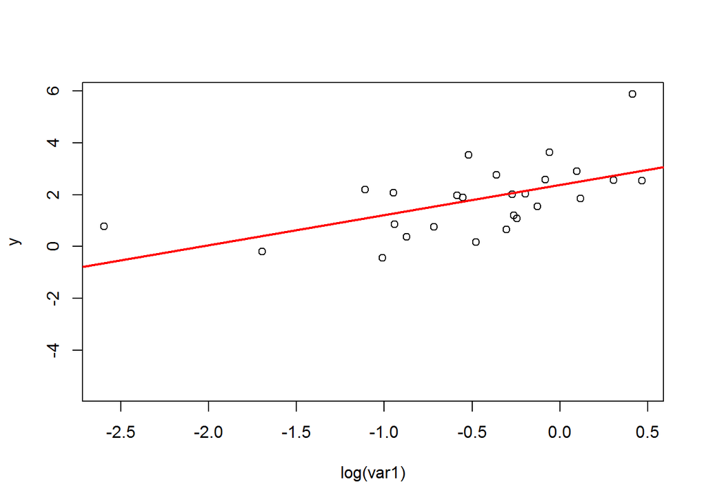

```r
plot(log(var1), y)
abline(modelo, col = 'red', lwd = 2)
```

# Visualizando propriedades do modelo

Outro passo importante na análise de modelos é verificar algumas de suas propriedades e os pressupostos são respeitados.

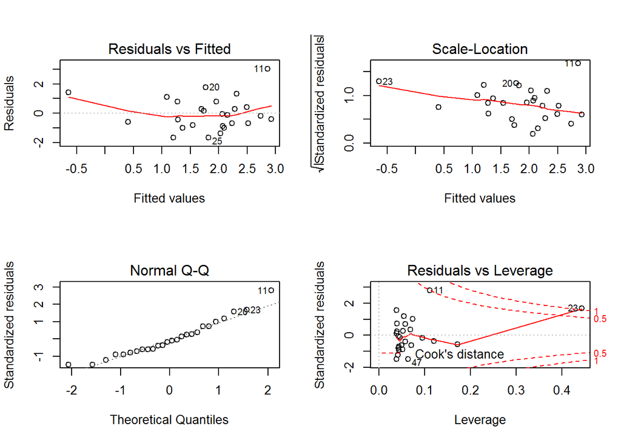

```r
layout(matrix(1:4, 2, 2))
 plot(modelo)
```

# Modelo Ensino Superior

Agora é sua hora de criar modelos para o lucro das instituições de ensino superior privada em função do número de profissionais em determinado nível de ensino. Crie um modelo para cada um dos níveis de ensino.

# ggplot2

## ggplot2

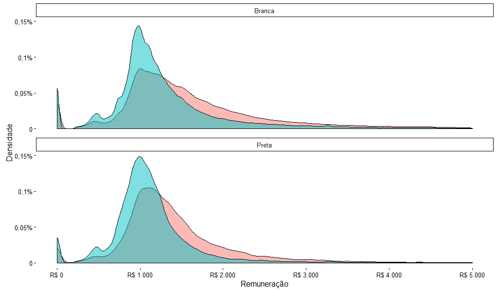

Remuneração por sexo e cor

## ggplot2

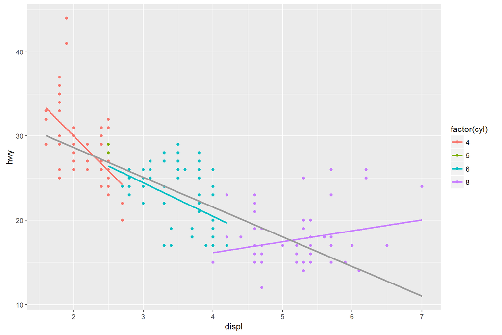

## Concepção do ggplot2

O ggplot2 é mais do que um pacote para fazer gráficos; ele é uma tentativa (muito bem sucedida) trazer para o dia-a-dia dos técnicos uma **gramática dos gráficos**.

#### Por que uma **gramática** dos gráficos?

Através dela podemos definir **sistematicamente** quais são os componentes de um gráficos e como eles se interelacionam.

Veja mais informações em [http://docs.ggplot2.org/](http://docs.ggplot2.org/current/).

## A gramática dos gráficos

| elemento | exemplos |
| --- | --- |
| dados (informação)* | seguro, fiscalizações |
| **(a)es**tética* | cor, formato |
| **geom**etrias* | barra, ponto |
| e**stat**ísticas | mediana, máximo |
| **facet**as | facetas |
| **coord**enadas | polar, cartesiana |
| **t(h)emas** | eixos, título |

## A camada de dados

A primeira etapa da construção de um gráfico é ter os dados que serão representados graficamente. Vamos carregar os dados dos vínculos da RAIS em 2014 para Santa Catarina

```r
vinculos_2014 <- readRDS('Microdados/vinculos_SC_2014.RDS')
 vinculos_2014 <- as.data.frame(vinculos_2014)
                  # Para tirar a classe data.table,
                  # não apresentada neste curso

 vinculos_2014 <- vinculos_2014[, c("Idade", "Mês Admissão",
                          "Raça Cor" , "Sexo Trabalhador",
                          "Vl Remun Média Nom", "Qtd Hora Contr")]
```

## Ainda os dados

Ainda precisamos melhorar um pouco a forma como os dados chegaram. Idade poderia ser mais útil em faixas; Mês Admissão, Cor e Sexo são variáveis categóricas.

```r
library(dplyr)
 vinculos_2014 <- vinculos_2014 %>%
   mutate(Admissão = factor(`Mês Admissão`,
                            labels = c('Não admitido ano', 'Jan', 'Fev',
                                       'Mar', 'Abr', 'Mai', 'Jun', 'Jul',
                                       'Ago', 'Set', 'Out', 'Nov', 'Dez')),
          Cor = factor(`Raça Cor`,
                       labels = c("Indígena", "Branca", "Preta", "Amarela",
                                  "Parda", "Não identificado", "Ignorado")),
          Sexo = factor(`Sexo Trabalhador`,
                        labels = c("Masculino", "Feminino")),
          Remuneração = as.numeric(gsub(pattern = ",", ".",
                                        `Vl Remun Média Nom`)))
```

## Faixas de Jornadas

```r
vinculos_2014$Jornada <- cut(vinculos_2014$`Qtd Hora Contr`,
                              breaks = c(-Inf, 20, 30, 40, Inf),
                              labels = c("Até 20", "Entre 20 e 30",
                                         "Entre 30 e 40", "Mais de 40"))

 set.seed(1) # semente de pseudo-aleatoriedade para reprodução

 # Vamos reduzir os dados para 200 observações aleatórias
 dados <- vinculos_2014[sample(1:nrow(vinculos_2014), 200), ]
```

## Mapeando dados na estética

Imagine que você fosse desenhar um gráfico. Como você decidiria até onde deve ir a barra ou onde ficariam os pontos? O computador também precisa de critérios para decidir como representar os dados, como a idade dos trabalhadores de Santa Catarina, em um gráfico.

Assim, a idade dos trabalhadores pode ser representada no eixo horizontal ou os grupos de idade podem aparecer como cores ou formato dos dados (menores de 30 triângulos, maiores quadrados).

## Aspectos Geométricos

Além de ter dados e mapeá-los em atributos estéticos, você deve escolher com que geometrias quer aprensentar seus dados.

As geometrias mais comuns são:

- Pontos (diagrama de dispersão)
- Barras
- Linhas
- Diagrama de baixa (boxplot)

Vamos ver como usar estas geometrias no `ggplot2`

## geom_point()

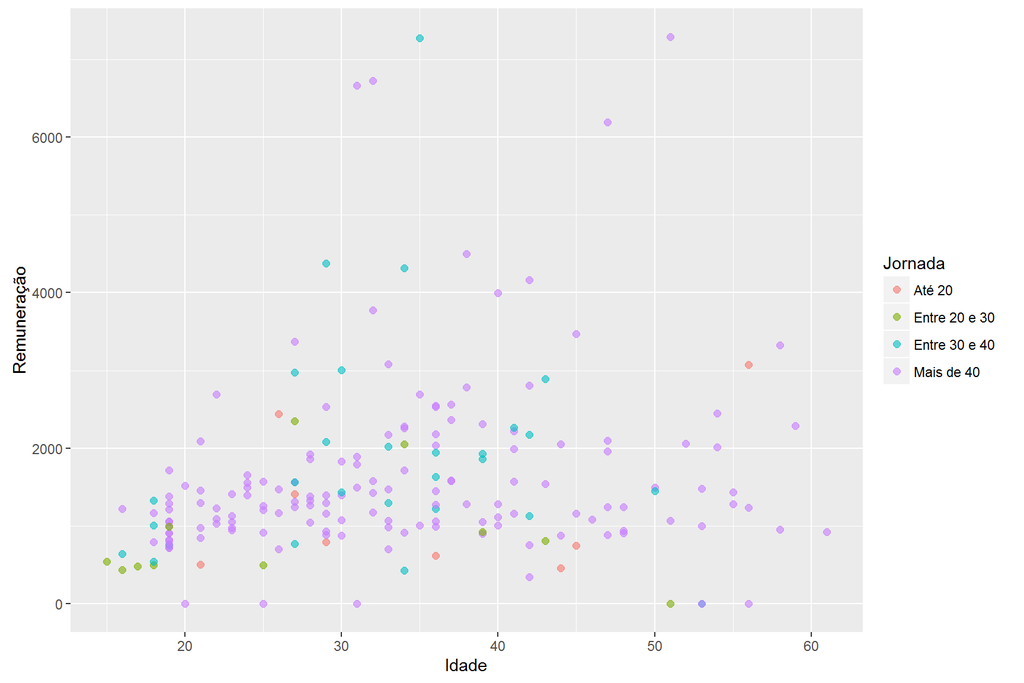

```r
ggplot(dados[dados$Remuneração < 10000, ], aes(Idade, Remuneração)) +
   geom_point(aes(color = Jornada), size = 2, alpha = 0.6)
```

## geom_bar()

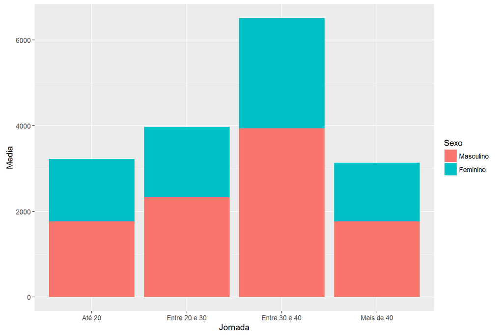

```r
medias <- vinculos_2014 %>% group_by(Jornada, Sexo) %>%
   summarise(Media = mean(Remuneração))

 ggplot(medias, aes(x = Jornada, y = Media, fill = Sexo)) +
   geom_bar(stat = "identity")
```

```r
# gráficos de barras são geralmente usados em estatísticas sumarizadas
```

## geom_histogram()

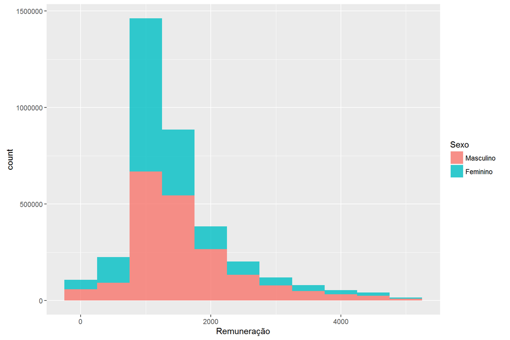

```r
ggplot(vinculos_2014 %>% filter(Remuneração < 5000),
        aes(x = Remuneração, fill = Sexo)) +
   geom_histogram(binwidth = 500, alpha= 0.8) # definir qtd de intervalos(bins)
```

## Ou então geom_density()

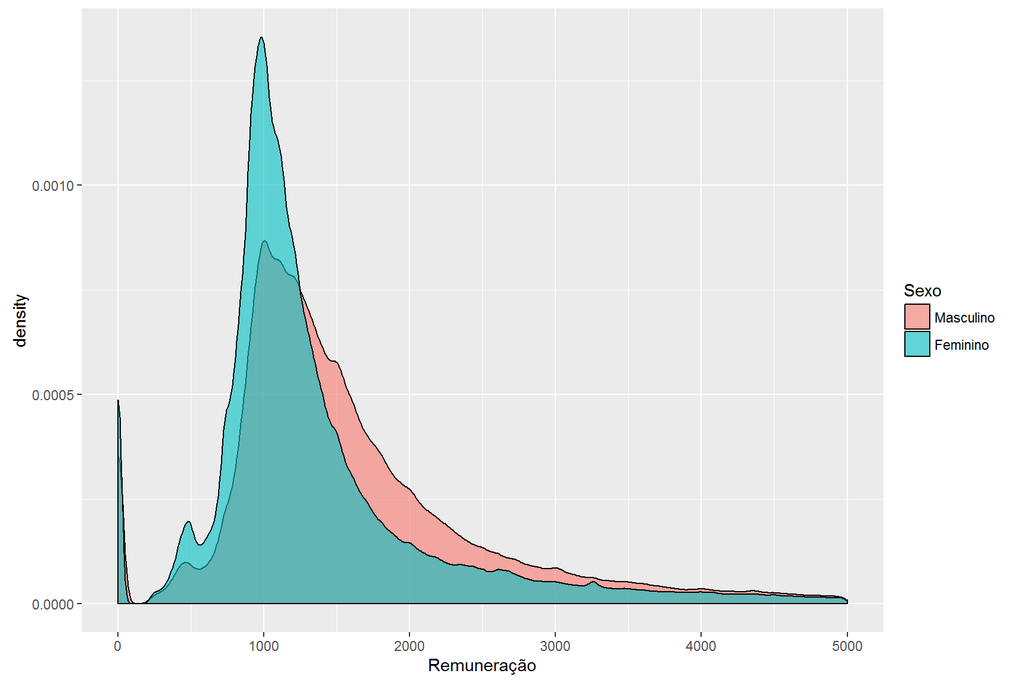

```r
ggplot(vinculos_2014 %>% filter(Remuneração < 5000),
        aes(x = Remuneração, fill = Sexo)) +
   geom_density(alpha= 0.6)
```

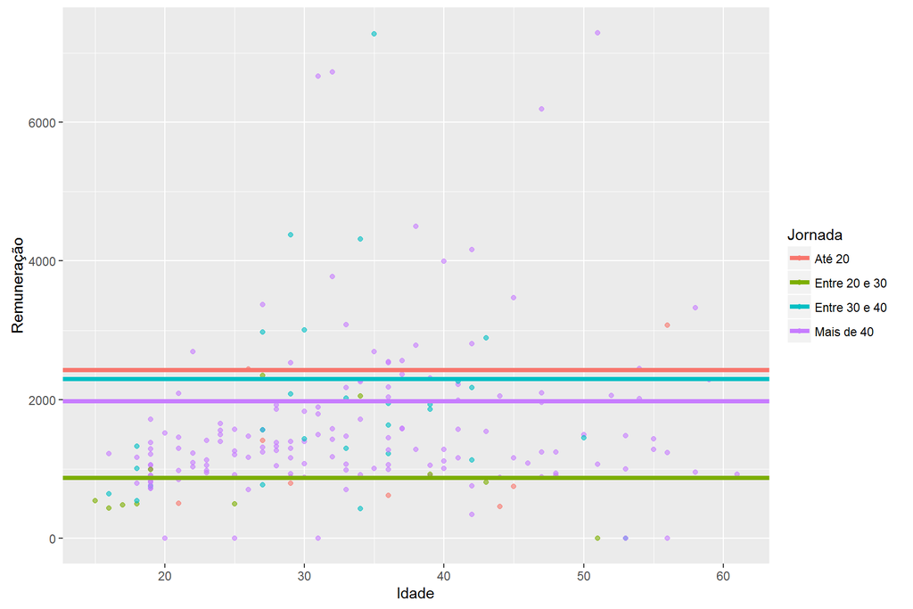

```r
medias <- dados %>% group_by(Jornada) %>%
   summarise(Media = mean(Remuneração))

 ggplot(dados[dados$Remuneração < 10000,], aes(Idade, Remuneração, col = Jornada)) +
   geom_point(alpha = 0.6) +
   geom_hline(aes(yintercept = Media, col = Jornada), data = medias, size = 1.5)
```

## geom_boxplot()

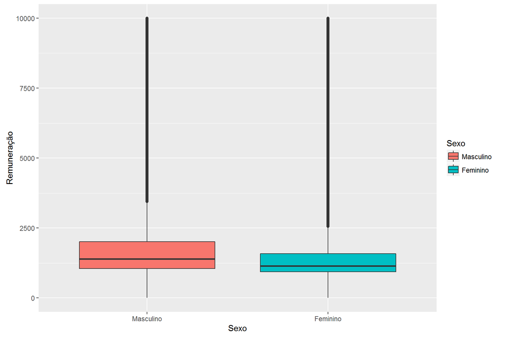

```r
ggplot(vinculos_2014 %>% filter(Remuneração < 10000),
        aes(x = Sexo, y = Remuneração, fill = Sexo)) +
   geom_boxplot()
```

## Estatísticas

Toda geometria está vinculada a alguma estatística. Esta estatística pode ser identidade, isto é, o dados tal qual. Mas, observem, seria impossível desenhar algumas geometrias sem obter algumas estatísticas sobre os dados. O ggplot2 faz isso por trás das cenas para nós.

Caso precisemos gerar as estatísticas, o `ggplot2` tem a família de funções `stat_*`. Vejamos um exemplo

## Estatísticas

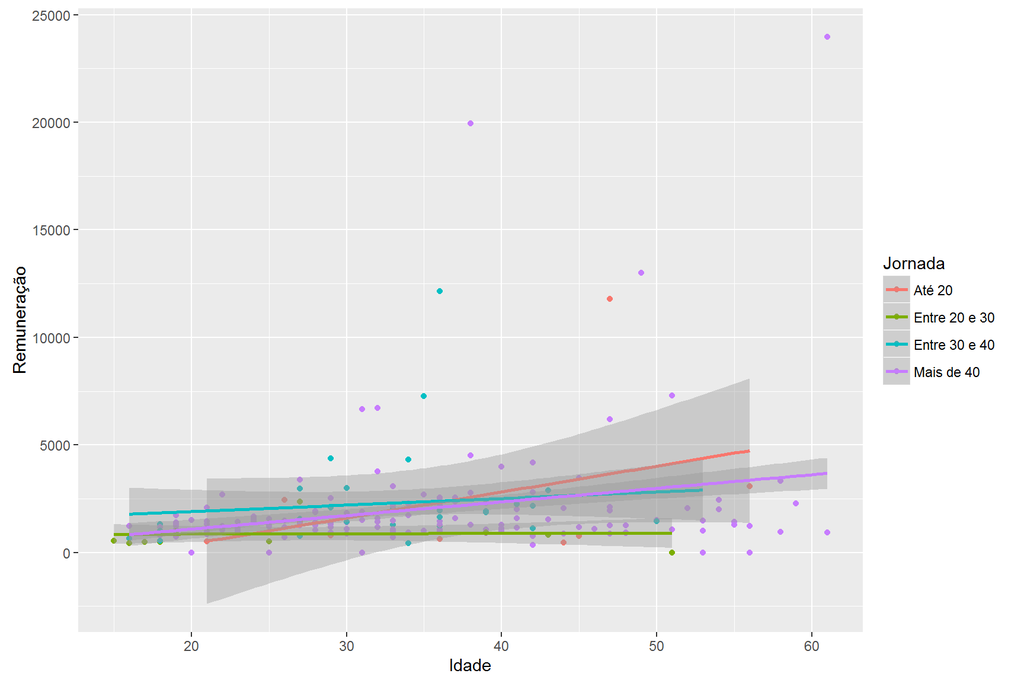

```r
ggplot(dados, aes(x = Idade, y = Remuneração, col = Jornada)) +
   geom_point() +
   stat_smooth(geom = "smooth", method = "lm", level = 0.8)
```

```r
# realizou calculos de regressão
```

## Coordenadas e Facetas

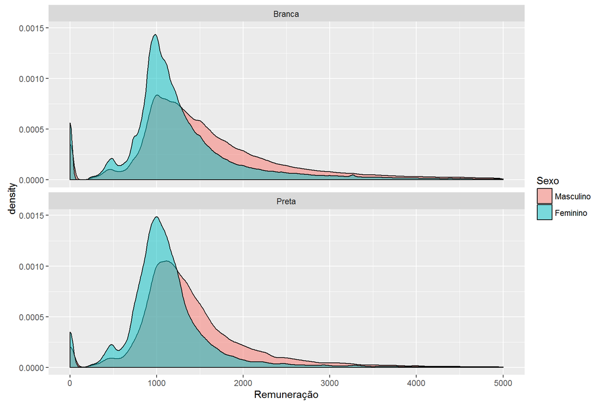

```r
menos_5 <- vinculos_2014[(vinculos_2014$Cor %in%
                               c("Preta", "Branca") &
                        vinculos_2014$Remuneração < 5000), ]
 ggplot(menos_5, aes(Remuneração, fill = Sexo)) +
   geom_density(alpha = 0.5) + facet_wrap(~Cor, dir = "v")
```

## Tema

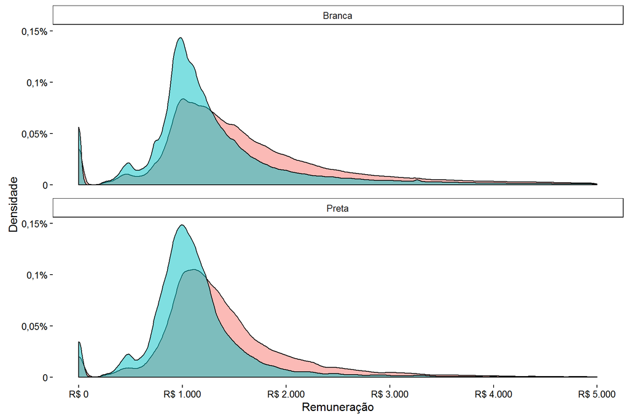

```r
ggplot(menos_5, aes(Remuneração, fill = Sexo)) +
   geom_density(alpha = 0.5) +   facet_wrap(~Cor, dir = "v") +
   theme_classic() +
   scale_y_continuous(name = "Densidade", labels = c("0", "0,05%", "0,1%", "0,15%"), minor_breaks = NULL) +
     scale_x_continuous(labels = c("R$ 0", "R$ 1.000", "R$ 2.000", "R$ 3.000", "R$ 4.000", "R$ 5.000"), minor_breaks = NULL) +
   theme(legend.position = 'none')
```